# atividade ponderada

2024-08-12

1. **Carregamento e Preparação dos Dados (20%)**

```r
# Instalar pacotes necessários
install.packages(c("tidyverse", "GGally", "corrplot", "gridExtra"))
# Carregar pacotes
library(tidyverse)
library(GGally)
library(corrplot)
library(gridExtra)
library(ggplot2)
```

Carregamento dos dados (7%): O aluno deve carregar corretamente o conjunto de dados fornecido.

Visualização das primeiras linhas (7%): Utilização da função head() ou equivalente para mostrar as primeiras linhas do conjunto de dados.

```r
head(dados)
```

```
##       cod_prod                      nome_abrev
## 1 603078352615    Acne Solutions Cleansing Bar
## 2 131384024501              Pep Start Daily UV
## 3  85873708529          Deep Comfort Body Wash
## 4 579926605113     Lipikar Wash Gentle Foaming
## 5 397769055946 Anthelios AOX Daily Antioxidant
## 6 981647487600            Basil White Tea Body
##                                        nome_completo
## 1       Acne Solutions Cleansing Bar for Face & Body
## 2 Pep Start Daily UV Protector Broad Spectrum SPF 50
## 3                             Deep Comfort Body Wash
## 4  Lipikar Wash AP+ Gentle Foaming Moisturizing Wash
## 5  Anthelios AOX Daily Antioxidant Face Serum SPF 50
## 6                        Basil & White Tea Body Wash
##                                                                                       descricao
## 1            Sabonete líquido Clinique Acne Solutions Cleansing Bar for Face & Body  para Corpo
## 2        Protetor solar Clinique Pep Start Daily UV Protector Broad Spectrum SPF 50  para Corpo
## 3                                  Sabonete líquido Clinique Deep Comfort Body Wash  para Corpo
## 4 Sabonete líquido La Roche-Posay Lipikar Wash AP+ Gentle Foaming Moisturizing Wash  para Corpo
## 5   Protetor solar La Roche-Posay Anthelios AOX Daily Antioxidant Face Serum SPF 50  para Corpo
## 6                                Sabonete líquido Nivea Basil & White Tea Body Wash  para Corpo
##   categoria    sub_categoria          marca conteudo_valor conteudo_medida
## 1     Corpo Sabonete líquido       Clinique            156              ml
## 2     Corpo   Protetor solar       Clinique             30              ml
## 3     Corpo Sabonete líquido       Clinique            204              ml
## 4     Corpo Sabonete líquido La Roche-Posay            405              ml
## 5     Corpo   Protetor solar La Roche-Posay             30              ml
## 6     Corpo Sabonete líquido          Nivea            600              ml
```

Verificação da estrutura dos dados (6%): Uso da função str() ou equivalente para verificar a estrutura dos dados.

```r
# Estrutura dos dados
str(dados)
```

```
## 'data.frame':    563 obs. of  9 variables:
##  $ cod_prod       : num  6.03e+11 1.31e+11 8.59e+10 5.80e+11 3.98e+11 ...
##  $ nome_abrev     : chr  "Acne Solutions Cleansing Bar" "Pep Start Daily UV" "Deep Comfort Body Wash" "Lipikar Wash Gentle Foaming" ...
##  $ nome_completo  : chr  "Acne Solutions Cleansing Bar for Face & Body" "Pep Start Daily UV Protector Broad Spectrum SPF 50" "Deep Comfort Body Wash" "Lipikar Wash AP+ Gentle Foaming Moisturizing Wash" ...
##  $ descricao      : chr  "Sabonete líquido Clinique Acne Solutions Cleansing Bar for Face & Body  para Corpo" "Protetor solar Clinique Pep Start Daily UV Protector Broad Spectrum SPF 50  para Corpo" "Sabonete líquido Clinique Deep Comfort Body Wash  para Corpo" "Sabonete líquido La Roche-Posay Li…
##  $ categoria      : chr  "Corpo" "Corpo" "Corpo" "Corpo" ...
##  $ sub_categoria  : chr  "Sabonete líquido" "Protetor solar" "Sabonete líquido" "Sabonete líquido" ...
##  $ marca          : chr  "Clinique" "Clinique" "Clinique" "La Roche-Posay" ...
##  $ conteudo_valor : num  156 30 204 405 30 600 600 600 252 201 ...
##  $ conteudo_medida: chr  "ml" "ml" "ml" "ml" ...
```

2. **Resumo Estatístico e Descrição dos Dados (20%)**

Resumo estatístico (10%): Utilização da função summary() ou equivalente para obter um resumo estatístico das variáveis.

```r
# Resumo estatístico das variáveis
summary(dados)
```

```
##     cod_prod          nome_abrev        nome_completo       descricao
##  Min.   :6.587e+09   Length:563         Length:563         Length:563
##  1st Qu.:2.506e+11   Class :character   Class :character   Class :character
##  Median :4.800e+11   Mode  :character   Mode  :character   Mode  :character
##  Mean   :5.024e+11
##  3rd Qu.:7.696e+11
##  Max.   :9.970e+11
##   categoria         sub_categoria         marca           conteudo_valor
##  Length:563         Length:563         Length:563         Min.   :   0.02
##  Class :character   Class :character   Class :character   1st Qu.:   3.50
##  Mode  :character   Mode  :character   Mode  :character   Median :  15.00
##                                                           Mean   :  69.28
##                                                           3rd Qu.:  61.50
##                                                           Max.   :1440.00
##  conteudo_medida
##  Length:563
##  Class :character
##  Mode  :character
##
##
##
```

Descrição das variáveis (10%): Descrição clara e concisa das variáveis presentes no conjunto de dados.

cod_prod:

Descrição: Código identificador único de cada produto. Tipo: Numérico (inteiro) Função: Serve para distinguir um produto do outro e pode ser utilizado como chave primária em um banco de dados. nome_abrev:

Descrição: Nome abreviado do produto. Tipo: Caractere Função: Nome curto e fácil de lembrar do produto, utilizado para referenciar o produto de forma concisa. nome_completo:

Descrição: Nome completo do produto. Tipo: Caractere Função: Descrição detalhada do produto, contendo informações sobre sua função e características. descricao:

Descrição: Subcategoria do produto. Tipo: Caractere Função: Divide a categoria em grupos mais específicos (ex: sabonete líquido, protetor solar, etc.). marca:

Descrição: Marca do produto. Tipo: Caractere Função: Indica o fabricante do produto. conteudo_valor:

Descrição: Quantidade do produto. Tipo: Numérico Função: Indica a quantidade do produto em uma unidade específica (ex: mililitros). conteudo_medida:

Descrição: Unidade de medida da quantidade do produto. Tipo: Caractere Função: Especifica a unidade utilizada para medir a quantidade do produto (ex: ml, g, etc.).

3. **Análise Univariada (25%)**

Visualização das distribuições (13%): Criação de histogramas, gráficos de densidade ou boxplots para as variáveis principais.

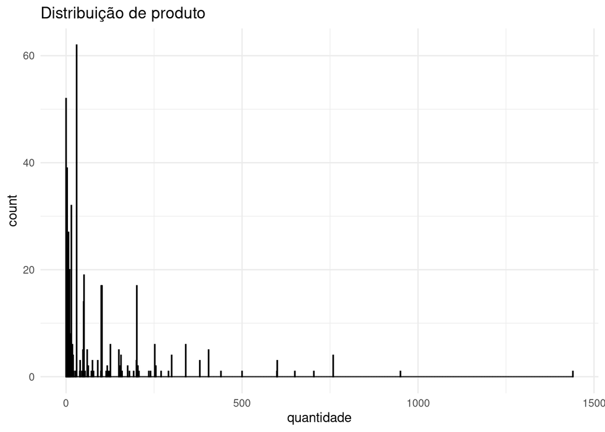

```r
# Histograma da variável 'quality'
ggplot(dados, aes(x = conteudo_valor)) +
  geom_histogram(binwidth = 1, fill = "blue", color = "black") +
  theme_minimal() +
  labs(title = "Distribuição de produto", x = "quantidade")
```

Identificação de outliers (12%): Identificação e discussão sobre outliers presentes nas variáveis.

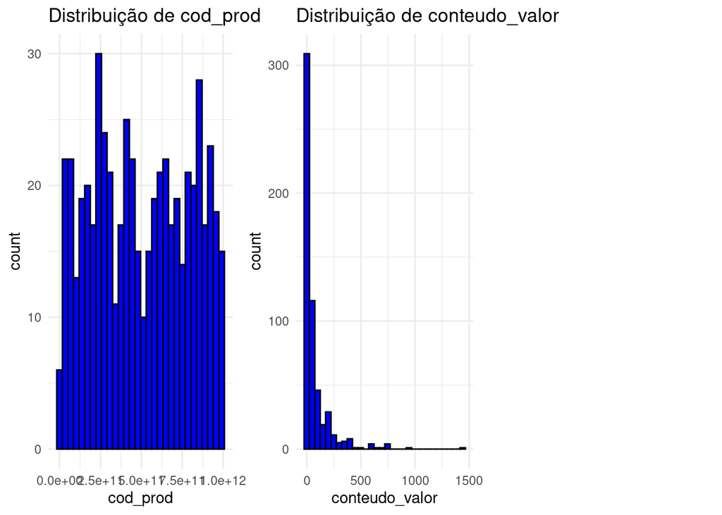

```r
# Seleciona apenas as variáveis numéricas
numeric_vars <- dados %>% select_if(is.numeric)

# Cria os histogramas para cada variável numérica
p <- lapply(names(numeric_vars), function(var) {
  ggplot(dados, aes_string(x = var)) +
    geom_histogram(fill = "blue", color = "black", bins = 30) +
    theme_minimal() +
    labs(title = paste("Distribuição de", var), x = var, )
})
# Exibe os gráficos em um layout com 3 colunas
grid.arrange(grobs = p, ncol = 3)
```

4. **Análise Bivariada (25%)**

Visualização de relações entre variáveis (13%): Criação de gráficos de dispersão (scatter plots) ou gráficos de barras para explorar relações entre variáveis.

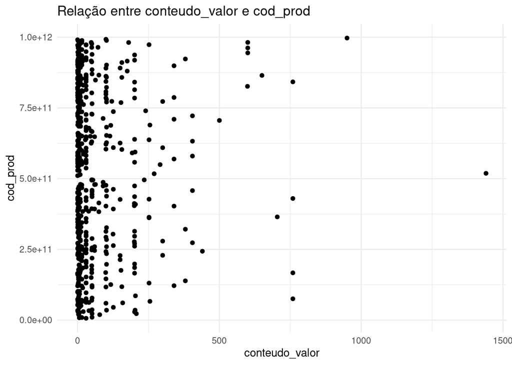

```r
# Scatter plot para duas variáveis numéricas
ggplot(dados, aes(x = conteudo_valor, y = cod_prod)) +
  geom_point() +
  theme_minimal() +
  labs(title = "Relação entre conteudo_valor e cod_prod", x = "conteudo_valor", y = "cod_prod")
```

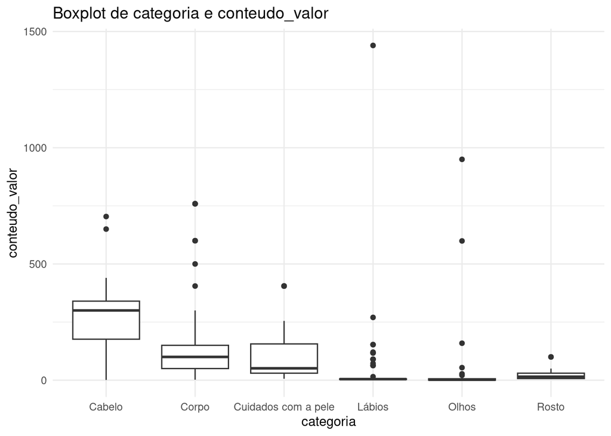

```r
# Boxplot para uma variável categórica e uma numérica
ggplot(dados, aes(x = categoria, y = conteudo_valor)) +
  geom_boxplot() +
  theme_minimal() +
  labs(title = "Boxplot de categoria e conteudo_valor", x = "categoria", y = "conteudo_valor")
```

Análise de correlação (12%): Cálculo e visualização da matriz de correlação entre as variáveis, usando cor() e corrplot().

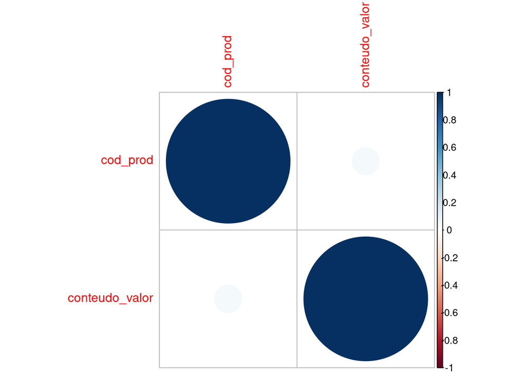

```r
# Matriz de correlação
cor_matrix <- cor(dados %>% select_if(is.numeric))
corrplot(cor_matrix, method = "circle")
```

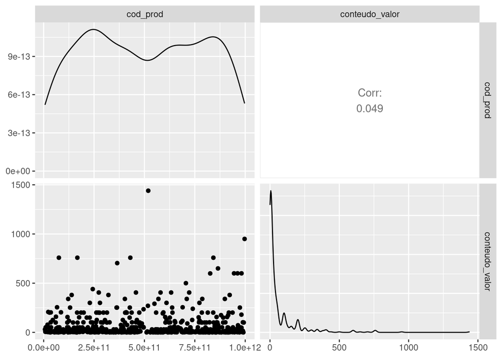

```r
# Scatterplot matrix
ggpairs(dados %>% select_if(is.numeric))
```

5. **Análise Multivariada (15%)**

Análise de Componentes Principais (PCA) (10%): Implementação de PCA utilizando FactoMineR ou prcomp(), e visualização dos resultados.

```r
library(ggfortify)

# Regressão linear simples
model <- lm(cod_prod ~ conteudo_valor, data = dados)
summary(model)
```

```
##
## Call:
## lm(formula = cod_prod ~ conteudo_valor, data = dados)
##
## Residuals:
##        Min         1Q     Median         3Q        Max
## -4.990e+11 -2.487e+11 -2.198e+10  2.654e+11  4.958e+11
##
## Coefficients:
##                 Estimate Std. Error t value Pr(>|t|)
## (Intercept)    4.951e+11  1.376e+10   35.98   <2e-16 ***
## conteudo_valor 1.044e+08  8.926e+07    1.17    0.242
## ---
## Signif. codes:  0 '***' 0.001 '**' 0.01 '*' 0.05 '.' 0.1 ' ' 1
##
## Residual standard error: 2.917e+11 on 561 degrees of freedom
## Multiple R-squared:  0.002435,   Adjusted R-squared:  0.0006566
## F-statistic: 1.369 on 1 and 561 DF,  p-value: 0.2424
```

```r
# Análise de componentes principais (PCA)
pca <- prcomp(dados %>% select_if(is.numeric), scale = TRUE)
summary(pca)
```

```
## Importance of components:
##                           PC1    PC2
## Standard deviation     1.0244 0.9750
## Proportion of Variance 0.5247 0.4753
## Cumulative Proportion  0.5247 1.0000
```

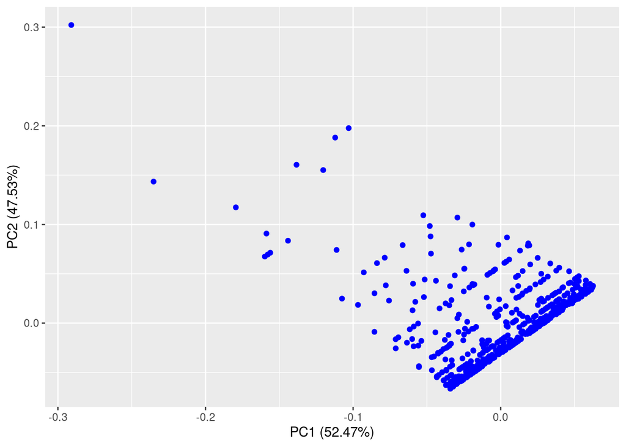

```r
# Visualização dos componentes principais
autoplot(pca, data = dados,colour = 'blue')
```